# Variable Selection

MATH 456 Solutions

February 26, 2016

```r
library(ggplot2);library(leaps);library(MASS)
library(dplyr);library(xtable); library(knitr)
lung  <- read.delim("C:/GitHub/MATH456/data/lung_020716.txt")
hiv <- read.delim("C:/GitHub/MATH456/data/PARHIV_022216.txt")
opts_chunk$set(warning=FALSE, message=FALSE, fig.align='center')
```

**1. For the lung function data, use an automated selection process to predict FEV1 for the oldest child using age, height, weight and FVC as candidate variables. State and justify the method and criteria you chose.**

```r
lung  <- lung %>% mutate(OCSEX = factor(OCSEX, labels=c("Male", "Female")))
lung2 <- lung %>% select(OCSEX, OCAGE, OCHEIGHT, OCWEIGHT, OCFEV1)
```

Specify the null and full models

```r
null <- lm(OCFEV1 ~ 1, data=lung2)
full <- lm(OCFEV1 ~ ., data=lung2)
```

Then run forwards, backwards and stepwise selection methods using the AIC as the selection criteria. Also run best subsets regression.

```r
fwd  <- stepAIC(null, scope=list(lower=null, upper=full), direction="forward")
```

```
## Start:  AIC=18.8
## OCFEV1 ~ 1
##
##            Df Sum of Sq     RSS      AIC
## + OCHEIGHT  1   143.074  24.703 -266.558
## + OCWEIGHT  1   133.891  33.886 -219.144
## + OCAGE     1   119.332  48.445 -165.532
## + OCSEX     1    14.708 153.069    7.038
## <none>                  167.777   18.800
##
## Step:  AIC=-266.56
## OCFEV1 ~ OCHEIGHT
##
##            Df Sum of Sq    RSS     AIC
## + OCWEIGHT  1    3.2783 21.424 -285.92
## + OCSEX     1    1.5179 23.185 -274.07
## <none>                  24.703 -266.56
## + OCAGE     1    0.0034 24.699 -264.58
##
## Step:  AIC=-285.91
## OCFEV1 ~ OCHEIGHT + OCWEIGHT
##
##         Df Sum of Sq    RSS     AIC
## + OCSEX  1   1.23019 20.194 -292.79
## <none>               21.424 -285.92
## + OCAGE  1   0.02795 21.397 -284.11
##
## Step:  AIC=-292.78
## OCFEV1 ~ OCHEIGHT + OCWEIGHT + OCSEX
##
##         Df Sum of Sq    RSS     AIC
## <none>               20.194 -292.79
## + OCAGE  1 0.0049403 20.189 -290.82
```

```r
back <- stepAIC(full, direction="backward")
```

```
## Start:  AIC=-290.82
## OCFEV1 ~ OCSEX + OCAGE + OCHEIGHT + OCWEIGHT
##
##            Df Sum of Sq    RSS     AIC
## - OCAGE     1    0.0049 20.194 -292.79
## <none>                  20.189 -290.82
## - OCSEX     1    1.2072 21.397 -284.11
## - OCWEIGHT  1    2.8972 23.087 -272.71
## - OCHEIGHT  1    6.6410 26.830 -250.16
##
## Step:  AIC=-292.78
## OCFEV1 ~ OCSEX + OCHEIGHT + OCWEIGHT
##
##            Df Sum of Sq    RSS     AIC
## <none>                  20.194 -292.79
## - OCSEX     1    1.2302 21.425 -285.92
## - OCWEIGHT  1    2.9906 23.185 -274.07
## - OCHEIGHT  1   12.1746 32.369 -224.01
```

```r
step <- stepAIC(null, scope=list(upper=full,lower=null), direction="both")
```

```
## Start:  AIC=18.8
## OCFEV1 ~ 1
##
##            Df Sum of Sq     RSS      AIC
## + OCHEIGHT  1   143.074  24.703 -266.558
## + OCWEIGHT  1   133.891  33.886 -219.144
## + OCAGE     1   119.332  48.445 -165.532
## + OCSEX     1    14.708 153.069    7.038
## <none>                  167.777   18.800
##
## Step:  AIC=-266.56
## OCFEV1 ~ OCHEIGHT
##
##            Df Sum of Sq     RSS     AIC
## + OCWEIGHT  1     3.278  21.425 -285.92
## + OCSEX     1     1.518  23.185 -274.07
## <none>                   24.703 -266.56
## + OCAGE     1     0.003  24.699 -264.58
## - OCHEIGHT  1   143.074 167.777   18.80
##
## Step:  AIC=-285.91
## OCFEV1 ~ OCHEIGHT + OCWEIGHT
##
##            Df Sum of Sq    RSS     AIC
## + OCSEX     1    1.2302 20.194 -292.79
## <none>                  21.425 -285.92
## + OCAGE     1    0.0279 21.397 -284.11
## - OCWEIGHT  1    3.2783 24.703 -266.56
## - OCHEIGHT  1   12.4616 33.886 -219.14
##
## Step:  AIC=-292.78
## OCFEV1 ~ OCHEIGHT + OCWEIGHT + OCSEX
##
##            Df Sum of Sq    RSS     AIC
## <none>                  20.194 -292.79
## + OCAGE     1    0.0049 20.189 -290.82
## - OCSEX     1    1.2302 21.425 -285.92
## - OCWEIGHT  1    2.9906 23.185 -274.07
## - OCHEIGHT  1   12.1746 32.369 -224.01
```

```r
subset <- regsubsets(OCFEV1 ~ .,data = lung2, nbest = 2, nvmax = NULL,
                     force.in = NULL, force.out = NULL, method = "exhaustive")
```

Let’s look at the final model chosen by all four methods.

```r
names(fwd$coefficients)
```

```
## [1] "(Intercept)" "OCHEIGHT"    "OCWEIGHT"    "OCSEXFemale"
```

```r
names(back$coefficients)
```

```
## [1] "(Intercept)" "OCSEXFemale" "OCHEIGHT"    "OCWEIGHT"
```

```r
names(step$coefficients)
```

```
## [1] "(Intercept)" "OCHEIGHT"    "OCWEIGHT"    "OCSEXFemale"
```

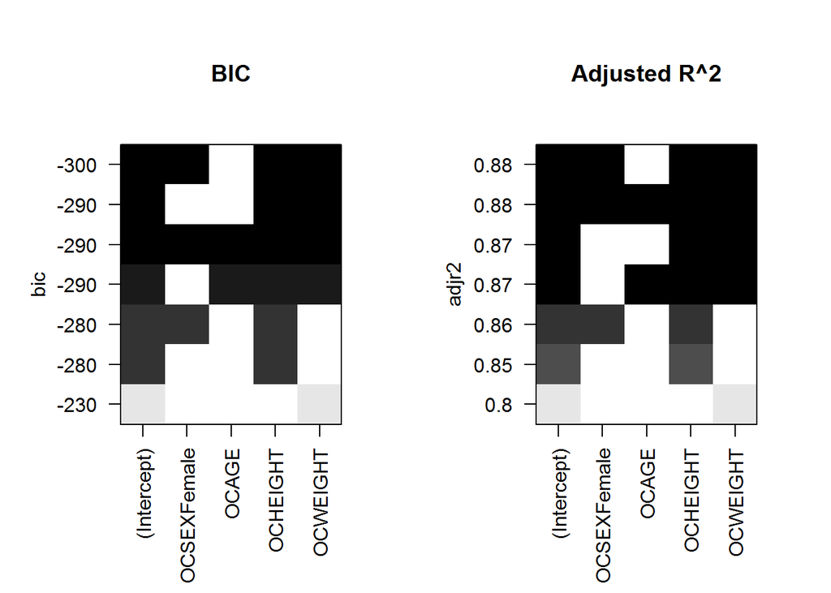

```r
par(mfrow=c(1,2))
plot(subset, scale="bic", main="BIC")
plot(subset, scale="adjr2", main="Adjusted R^2")
```

All automated procedures ended up identifying a model with gender, height and weight as variables predictive of FEV1 for the oldest child. Forward, backward and stepwise models were chosen based on the best (lowest) AIC value, the best subsets models were ranked using BIC and adjusted $R^{2}$.

**2. Take the variables you selected in problem 2 and build a linear regression model with `OCFEV1` as the dependent variable, and test whether including the FEV1 of the parents (`MFEV1` and `FFEV1` taken as a pair) in the model significantly improves the regression.**

A Likelihood ratio (Deviance) test is used to simultaneously test the effects of multiple variables the same time.

The full model includes the automatically chosen variables, and the parents FEV1 values.

```r
full <- lm(OCFEV1 ~ OCHEIGHT + OCWEIGHT + OCSEX + FFEV1 + MFEV1, data=lung)
```

The reduced model excludes those parental variables.

```r
reduced <- lm(OCFEV1 ~ OCHEIGHT + OCWEIGHT + OCSEX, data=lung)
```

An F test is then conducted to see if parental FEV adds a significant amount of information to the model of the oldest child’s FEV measurement.

$H_{0}: \beta_{4} = \beta_{5} = 0$  
$H_{a}:$ At least one is not zero.

```r
anova(full, reduced)
```

```
## Analysis of Variance Table
##
## Model 1: OCFEV1 ~ OCHEIGHT + OCWEIGHT + OCSEX + FFEV1 + MFEV1
## Model 2: OCFEV1 ~ OCHEIGHT + OCWEIGHT + OCSEX
##   Res.Df    RSS Df Sum of Sq      F   Pr(>F)
## 1    144 18.463
## 2    146 20.194 -2   -1.7315 6.7523 0.001574 **
## ---
## Signif. codes:  0 '***' 0.001 '**' 0.01 '*' 0.05 '.' 0.1 ' ' 1
```

There is sufficient evidence to believe that the FEV1 measurement for at least one parent is significantly predictive of the FEV1 measurement for the oldest child.

**3. Using the Parental HIV data find the best model that predicts the age at which adolescents started drinking alcohol. Since the data were collected retrospectively, only consider variables which might be considered representative of the time before the adolescent started drinking alcohol.**

Since alcohol use tends to be associated with smoking and marijuana use, I first exclude those variables from the pool of possible variables. At the same time I exclude all records where the adolescent has not started drinking yet.

```r
hiv1 <- hiv %>% select(-SMOKEP3M, -AGEMAR, -AGESMOKE) %>%
                filter(!is.na(AGEALC) & AGEALC > 0)
```

I then also take the time to make sure factor variables are being treated as actual factors. This code then will be moved into the data management file after this point because it is a change that should be done permanently to the data set. *I am leaving the ordinal variables unchanged*. I am also creating the neighborhood score variable as introduced in the multiple regression chapter.

```r
hiv2 <- hiv1 %>%
  mutate(LIVWITH = factor(LIVWITH, labels=c("Both", "One parent", "Other")),
         SIBLINGS = factor(SIBLINGS , labels=c("No", "Yes")),
         JOBMO = factor(JOBMO, labels=c("Employed", "Unemployed", "Retired/Disabled")),
         EDUMO = factor(EDUMO, labels=c("<HS", "HS/GED", "Post HS")),
         HOWREL = factor(HOWREL), ATTSERV = factor(ATTSERV),
         MONFOOD = factor(MONFOOD, labels=c("No", "Sometimes", "Yes")),
         FINSIT = factor(FINSIT, labels=c("Very Poor", "Poor", "OK", "Comf")),
         ETHN = factor(ETHN, labels=c("Latino", "NH - Black", "Other")),
         FRNDS = factor(FRNDS, labels=c("A good group of good friends",
                                        "1-2 good friends, lots acquaint.",
                                        "1-2 good friends, few acquaint.",
                                        "Not close to anyone")),
         SCHOOL = factor(SCHOOL), LIKESCH = factor(LIKESCH),
         HMONTH = factor(HMONTH))
hiv2 <- hiv2 %>% rowwise() %>%
        mutate(NGHB = sum(c(NGHB1,NGHB2,NGHB3,NGHB4,NGHB5,NGHB6,NGHB7,NGHB8,NGHB9,NGHB10,NGHB11)))
```

Next, I trim down the list of potential predictors by looking at `names(hiv2)` and dropping variables using their column number.

```r
hiv3 <- hiv2[,-c(1,10:20, 28, 31:108)]
```

Lets check the relationship between the age when the adolescent started drinking and the other continuous measurements in the data set by doing simple scatterplots.

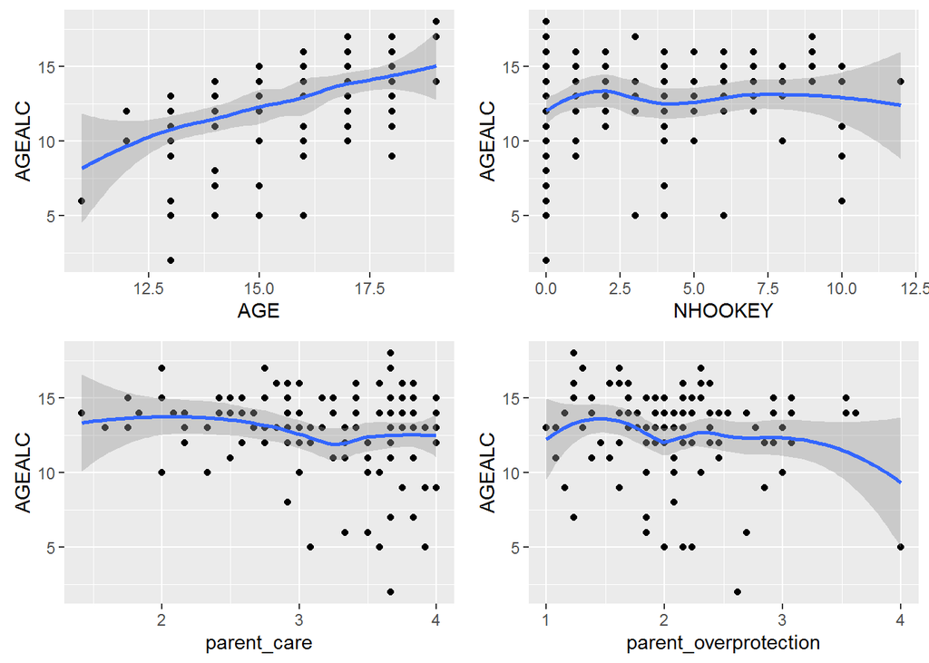

```r
library(gridExtra)
a <- qplot(y=AGEALC, x=AGE, data=hiv3, geom=c("point", "smooth"))
b <- qplot(y=AGEALC, x=NHOOKEY, data=hiv3, geom=c("point", "smooth"))
d <- qplot(y=AGEALC, x=parent_care, data=hiv3, geom=c("point", "smooth"))
e <- qplot(y=AGEALC, x=parent_overprotection, data=hiv3, geom=c("point", "smooth"))
grid.arrange(a,b,d,e, ncol=2)
```

It make sense that age has a linear relationship with the age in which the adolescent starts drinking.

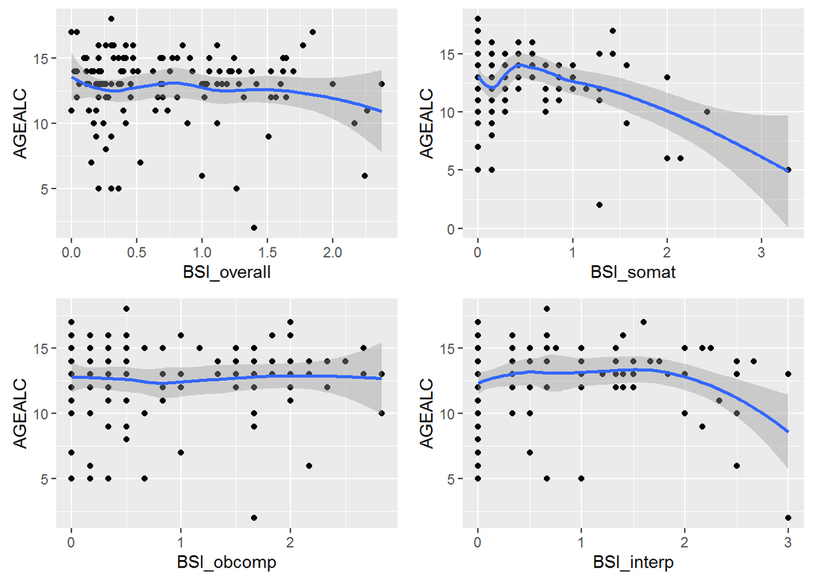

```r
a <- qplot(y=AGEALC, x=BSI_overall, data=hiv3, geom=c("point", "smooth"))
b <- qplot(y=AGEALC, x=BSI_somat, data=hiv3, geom=c("point", "smooth"))
d <- qplot(y=AGEALC, x=BSI_obcomp, data=hiv3, geom=c("point", "smooth"))
e <- qplot(y=AGEALC, x=BSI_interp, data=hiv3, geom=c("point", "smooth"))
grid.arrange(a,b,d,e, ncol=2)
```

`BSI_somat` and `BSI_interp` may have a curvilinear relationship with `AGEALC`, or perhaps there is a certain spot (`BSI_somat>1`?, `BSI_interp>2`?) where the relationship changes.

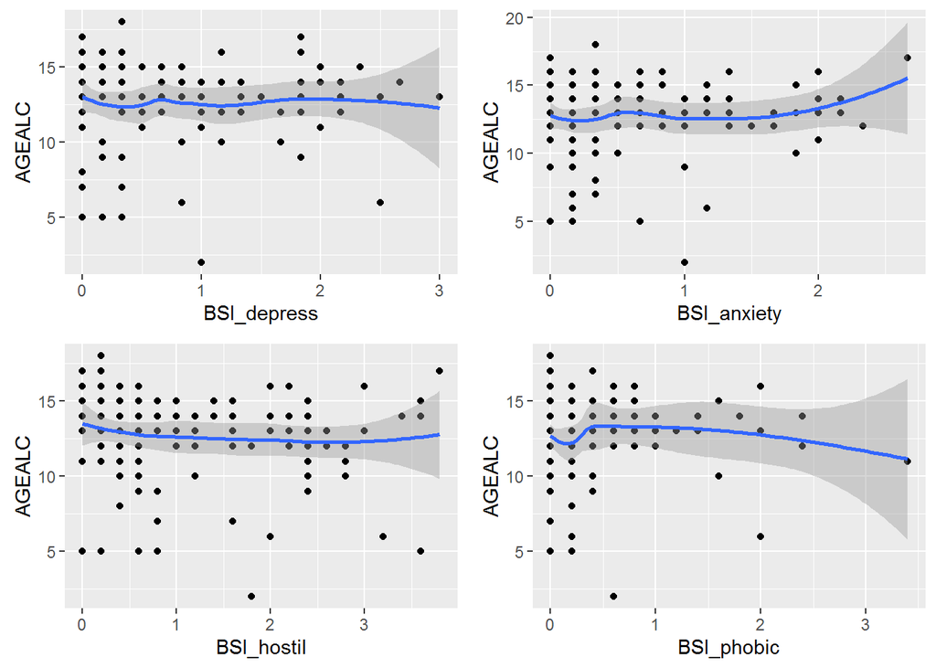

```r
a <- qplot(y=AGEALC, x=BSI_depress, data=hiv3, geom=c("point", "smooth"))
b <- qplot(y=AGEALC, x=BSI_anxiety, data=hiv3, geom=c("point", "smooth"))
d <- qplot(y=AGEALC, x=BSI_hostil, data=hiv3, geom=c("point", "smooth"))
e <- qplot(y=AGEALC, x=BSI_phobic, data=hiv3, geom=c("point", "smooth"))
grid.arrange(a,b,d,e, ncol=2)
```

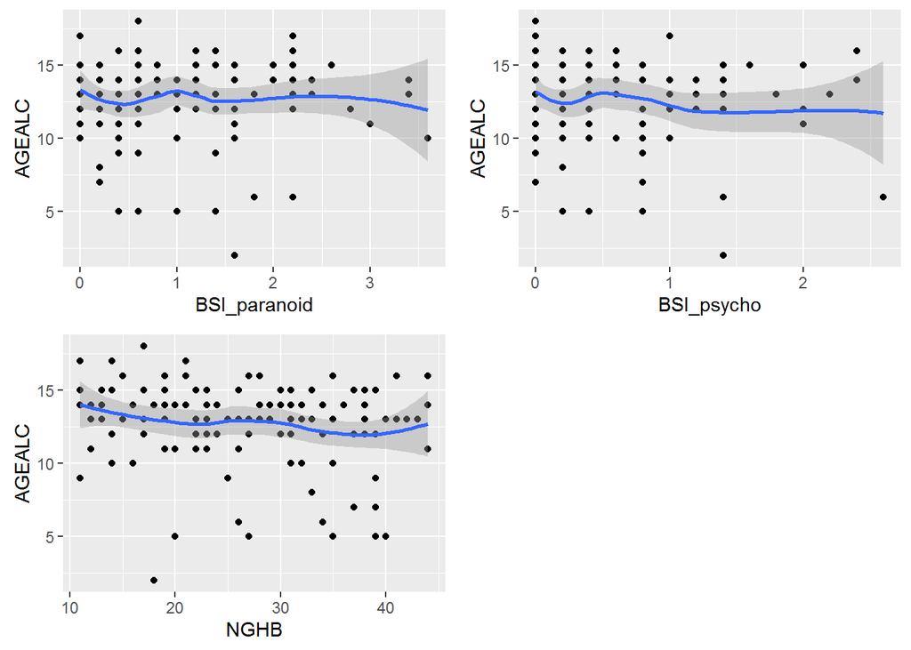

```r
a <- qplot(y=AGEALC, x=BSI_paranoid, data=hiv3, geom=c("point", "smooth"))
b <- qplot(y=AGEALC, x=BSI_psycho, data=hiv3, geom=c("point", "smooth"))
d <- qplot(y=AGEALC, x=NGHB, data=hiv3, geom=c("point", "smooth"))
grid.arrange(a,b,d, ncol=2)
```

The rest look pretty linear.

#### Consider non-linear terms

```r
library(splines)
i1 <- (hiv3$BSI_interp-2)
i1[ i1<0 ] <- 0

test_lin_spline <- lm(hiv3$AGEALC ~ hiv3$BSI_interp + i1)
summary(test_lin_spline)
```

```
##
## Call:
## lm(formula = hiv3$AGEALC ~ hiv3$BSI_interp + i1)
##
## Residuals:
##     Min      1Q  Median      3Q     Max
## -8.1454 -0.9803  0.4614  1.8013  5.0682
##
## Coefficients:
##                 Estimate Std. Error t value Pr(>|t|)
## (Intercept)      12.5047     0.3528   35.44  < 2e-16 ***
## hiv3$BSI_interp   0.6406     0.3930    1.63  0.10562
## i1               -6.0091     1.9321   -3.11  0.00232 **
## ---
## Signif. codes:  0 '***' 0.001 '**' 0.01 '*' 0.05 '.' 0.1 ' ' 1
##
## Residual standard error: 2.775 on 123 degrees of freedom
## Multiple R-squared:  0.07418,    Adjusted R-squared:  0.05913
## F-statistic: 4.928 on 2 and 123 DF,  p-value: 0.008735
```

The coefficient for the knot is significant, so it should be included in the model. We can also check the AIC for each model.

```r
lin_model <- lm(hiv3$AGEALC ~ hiv3$BSI_interp)
AIC(test_lin_spline)
```

```
## [1] 619.7656
```

```r
AIC(lin_model)
```

```
## [1] 627.3044
```

The difference in AIC between the two models is decently large. A difference over 3 or so indicates that the models are likely significantly different. Since these models are nested, we can perform a global F test to confirm this.

```r
anova(test_lin_spline, lin_model)
```

```
## Analysis of Variance Table
##
## Model 1: hiv3$AGEALC ~ hiv3$BSI_interp + i1
## Model 2: hiv3$AGEALC ~ hiv3$BSI_interp
##   Res.Df     RSS Df Sum of Sq      F   Pr(>F)
## 1    123  947.37
## 2    124 1021.87 -1   -74.505 9.6733 0.002324 **
## ---
## Signif. codes:  0 '***' 0.001 '**' 0.01 '*' 0.05 '.' 0.1 ' ' 1
```

Notice that since only one variable was added to the linear model, the F test and for the T-test that the beta coefficient is zero results in the exact same p-value. This is not a coincidence.

But what about that wiggle around 0.5? Let’s fit a natural spline, and see if that improves the fit.

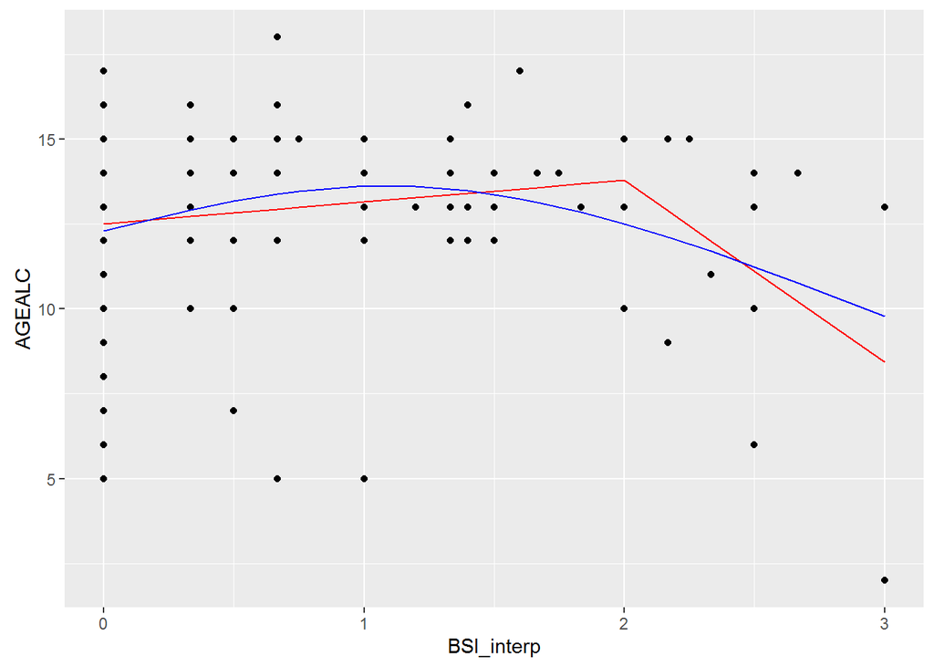

```r
test_ns <- lm(hiv3$AGEALC ~ ns(hiv3$BSI_interp,3))

ggplot(hiv3, aes(x=BSI_interp, y=AGEALC)) + geom_point() +
  geom_line(aes(x=BSI_interp, y=predict(test_lin_spline)), col="red") +
  geom_line(aes(x=BSI_interp, y=predict(test_ns)), col="blue")
```

This provides a smoother fit, but is it necessarily better?

```r
AIC(test_lin_spline)
```

```
## [1] 619.7656
```

```r
AIC(test_ns)
```

```
## [1] 621.2188
```

The difference is pretty negligible. So we stick with the simpler model and keep the knot at 2.

```r
s1 <- (hiv3$BSI_somat-1)
s1[ s1<0 ] <- 0

test_lin_spline <- lm(hiv3$AGEALC ~ hiv3$BSI_somat + s1)
summary(test_lin_spline)
```

```
##
## Call:
## lm(formula = hiv3$AGEALC ~ hiv3$BSI_somat + s1)
##
## Residuals:
##      Min       1Q   Median       3Q      Max
## -10.1208  -0.9819   0.0614   1.9809   5.3749
##
## Coefficients:
##                Estimate Std. Error t value Pr(>|t|)
## (Intercept)     12.9386     0.3411  37.926   <2e-16 ***
## hiv3$BSI_somat   0.1735     0.7372   0.235   0.8143
## s1              -3.6431     1.4191  -2.567   0.0115 *
## ---
## Signif. codes:  0 '***' 0.001 '**' 0.01 '*' 0.05 '.' 0.1 ' ' 1
##
## Residual standard error: 2.7 on 123 degrees of freedom
## Multiple R-squared:  0.1237, Adjusted R-squared:  0.1095
## F-statistic: 8.685 on 2 and 123 DF,  p-value: 0.0002963
```

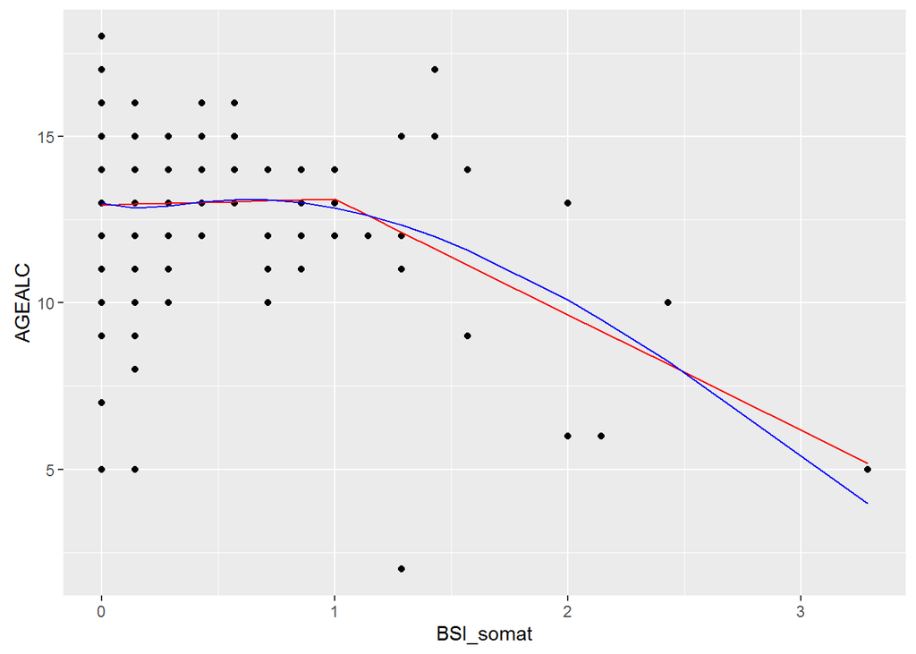

```r
test_ns <- lm(hiv3$AGEALC ~ ns(hiv3$BSI_somat,3))

ggplot(hiv3, aes(x=BSI_somat, y=AGEALC)) + geom_point() +
  geom_line(aes(x=BSI_somat, y=predict(test_lin_spline)), col="red") +
  geom_line(aes(x=BSI_somat, y=predict(test_ns)), col="blue")
```

Compare AIC

```r
AIC(test_ns)
```

```
## [1] 614.0029
```

```r
AIC(test_lin_spline)
```

```
## [1] 612.8332
```

Again, no real difference in fit.

What do we do with this information? Well we know that the final model of `AGEALC` should include `BSI_somat`, `BSI_interp` and their respective knots.

### Automated procedures

At this point if I try to put all the variables into a best subset model, I get an error message about linear dependencies. This is another indicator that there is multicolinearity going on, that is, at least two variables have a correlation of nearly 1 -or- that one variable is a linear combination of other variables.

```r
test <- regsubsets(AGEALC ~ ., data = hiv3, nbest = 2,
                     force.in = 1, method = "exhaustive")
```

```
## Reordering variables and trying again:
```

I can see if the problem stems from a continuous variable by creating a subset with only continuous variables and trying the subset model again.

```r
cont <- hiv3[,c(1,12,16,18:30)]

test_c <- regsubsets(AGEALC ~ ., data = cont, nbest = 2,
                     force.in = 1, method = "exhaustive")
```

No error, what are the results?

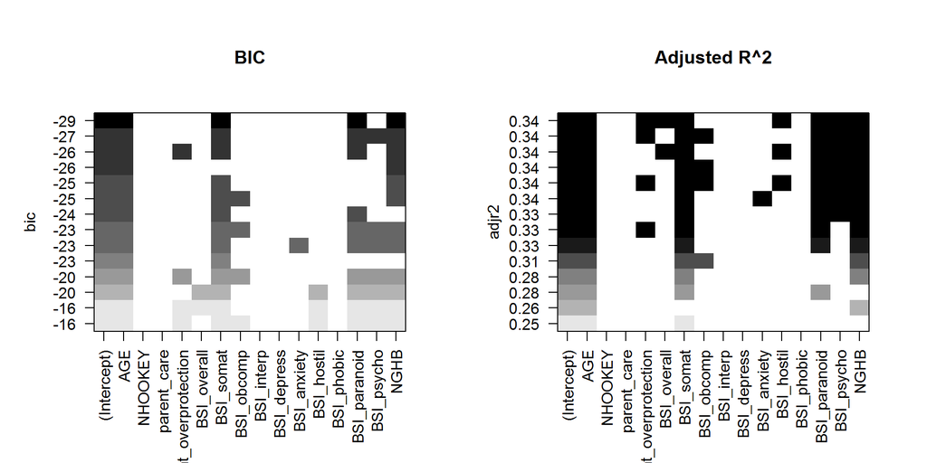

```r
par(mfrow=c(1,2))
plot(test_c, scale="bic", main="BIC")
plot(test_c, scale="adjr2", main="Adjusted R^2")
```

Interesting, looks like `BSI_anxiety` almost never makes it in, but then again, `BSI_interp` also does not rank high among the commonly selected variables.

So no error, so the problem with linear dependency involves a categorical variable, which there are a handful of.

```r
cat <- cbind(hiv3[,12], hiv3[,-c(1,12,16,18:30)])
summary(cat)
```

```
##      AGEALC         GENDER         LIVWITH   SIBLINGS
##  Min.   : 2.00   Female:65   Both      :19   No  :  7
##  1st Qu.:12.00   Male  :61   One parent:90   Yes :118
##  Median :13.00               Other     :17   NA's:  1
##  Mean   :12.72
##  3rd Qu.:14.00
##  Max.   :18.00
##               JOBMO        EDUMO     HOWREL   ATTSERV        MONFOOD
##  Employed        :13   <HS    :42   1   :10   1   :40   No       : 8
##  Unemployed      :51   HS/GED :30   2   :70   2   :38   Sometimes:22
##  Retired/Disabled:47   Post HS:22   3   :31   3   :31   Yes      :96
##  NA's            :15   NA's   :32   NA's:15   NA's:17
##
##
##        FINSIT           ETHN                                 FRNDS
##  Very Poor: 6   Latino    :64   A good group of good friends    :48
##  Poor     :17   NH - Black:44   1-2 good friends, lots acquaint.:53
##  OK       :36   Other     :18   1-2 good friends, few acquaint. :18
##  Comf     :67                   Not close to anyone             : 5
##                                 NA's                            : 2
##
##  SCHOOL  LIKESCH HMONTH
##  1: 23   1:23    1:52
##  2:103   2:46    3:74
##          3:29
##          4:11
##          5:17
##
```

So, we do a combo of manual and automated procedures. I manually ran the code chunk below, each time changing the data set to include more variables until I run into the error again.

```r
regsubsets(AGEALC ~ ., data = cat[,1:12], nbest = 2,
            method = "exhaustive")
```

```
## Subset selection object
## Call: regsubsets.formula(AGEALC ~ ., data = cat[, 1:12], nbest = 2,
##     method = "exhaustive")
## 22 Variables  (and intercept)
##                                       Forced in Forced out
## GENDERMale                                FALSE      FALSE
## LIVWITHOne parent                         FALSE      FALSE
## LIVWITHOther                              FALSE      FALSE
## SIBLINGSYes                               FALSE      FALSE
## JOBMOUnemployed                           FALSE      FALSE
## JOBMORetired/Disabled                     FALSE      FALSE
## EDUMOHS/GED                               FALSE      FALSE
## EDUMOPost HS                              FALSE      FALSE
## HOWREL2                                   FALSE      FALSE
## HOWREL3                                   FALSE      FALSE
## ATTSERV2                                  FALSE      FALSE
## ATTSERV3                                  FALSE      FALSE
## MONFOODSometimes                          FALSE      FALSE
## MONFOODYes                                FALSE      FALSE
## FINSITPoor                                FALSE      FALSE
## FINSITOK                                  FALSE      FALSE
## FINSITComf                                FALSE      FALSE
## ETHNNH - Black                            FALSE      FALSE
## ETHNOther                                 FALSE      FALSE
## FRNDS1-2 good friends, lots acquaint.     FALSE      FALSE
## FRNDS1-2 good friends, few acquaint.      FALSE      FALSE
## FRNDSNot close to anyone                  FALSE      FALSE
## 2 subsets of each size up to 8
## Selection Algorithm: exhaustive
```

```r
names(cat)[12]
```

```
## [1] "FRNDS"
```

So let’s force that out of the model and we’ll look at it later. No more errors after that.

```r
ms_cat <- regsubsets(AGEALC ~ ., data = cat[,c(1:11, 13:15)], nbest = 2,
                     method = "exhaustive")
```

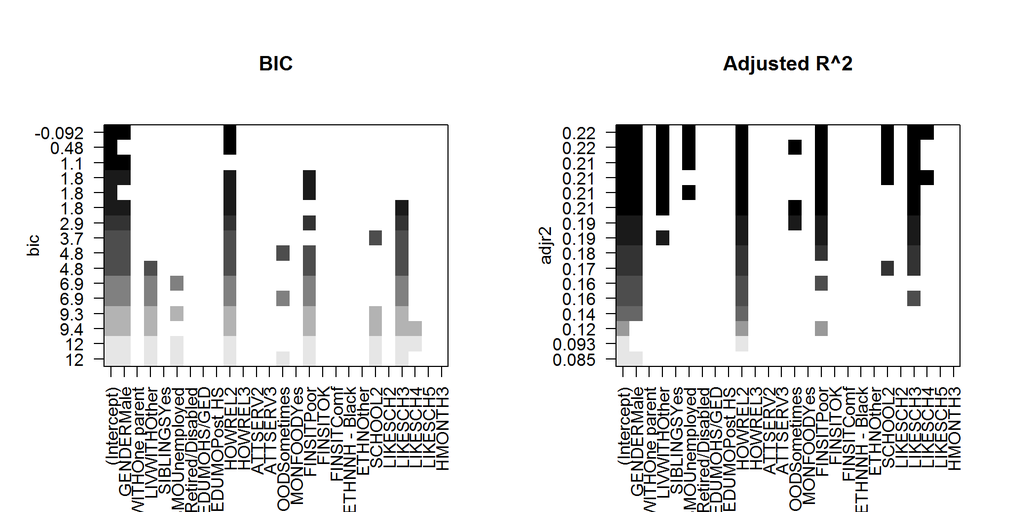

```r
par(mfrow=c(1,2))
plot(ms_cat, scale="bic", main="BIC")
plot(ms_cat, scale="adjr2", main="Adjusted R^2")
```

`HMONTH`, `ATTSERV`, Ethnicity and mom’s education level don’t seem to show up at all. Let’s drop them from the considered pool for now, but we should go back and check Ethnicity one last time before finalizing the model. It typically is a very important demographic.

```r
hiv4 <- hiv3 %>% select(-BSI_anxiety, -HMONTH, -ATTSERV,
                        -EDUMO, -ETHN, -FRNDS)
```

Putting *all* the remaining candidate variables into a selection process one last time.

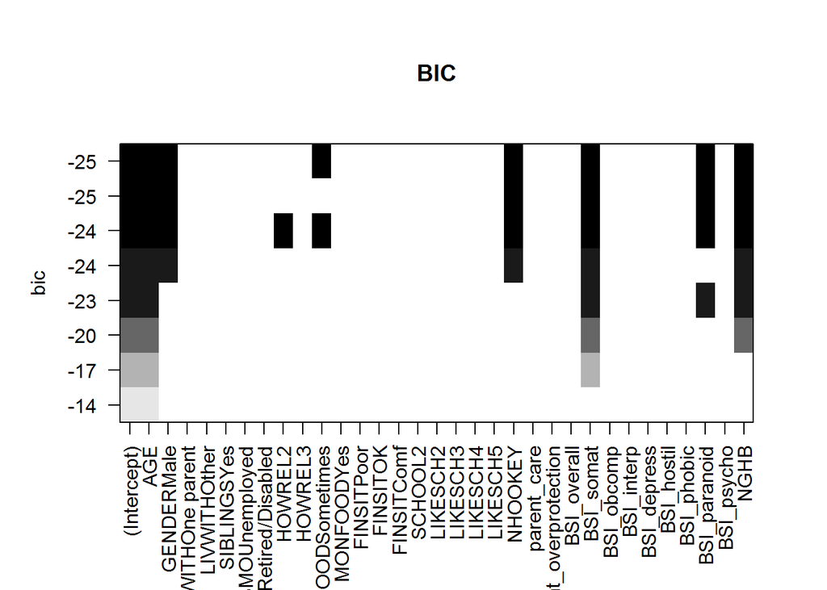

```r
test4 <- regsubsets(AGEALC ~ ., data = hiv4, nbest = 1,
                     method = "exhaustive")
plot(test4, scale="bic", main="BIC")
```

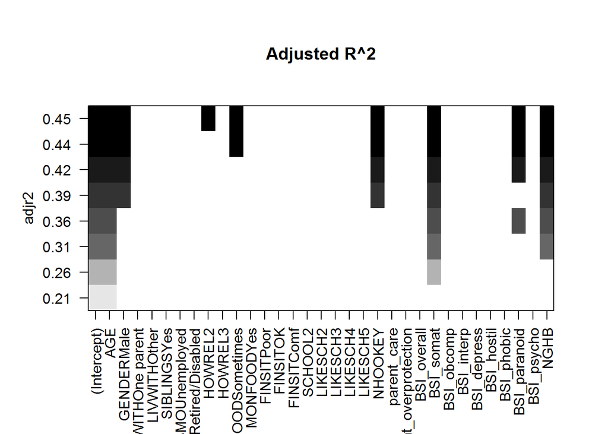

```r
plot(test4, scale="adjr2", main="Adjusted R^2")
```

```r
base_model <- lm(AGEALC ~ AGE + GENDER + HOWREL + BSI_somat +
                   NHOOKEY + BSI_paranoid + NGHB, data=hiv3)
```

Test the knot for `BSI_somat`.

```r
test_somat_knot <- lm(AGEALC ~ AGE + GENDER + HOWREL + BSI_somat + s1 +
                      NHOOKEY + BSI_paranoid + NGHB, data=hiv3)
anova(base_model, test_somat_knot)
```

```
## Analysis of Variance Table
##
## Model 1: AGEALC ~ AGE + GENDER + HOWREL + BSI_somat + NHOOKEY + BSI_paranoid +
##     NGHB
## Model 2: AGEALC ~ AGE + GENDER + HOWREL + BSI_somat + s1 + NHOOKEY + BSI_paranoid +
##     NGHB
##   Res.Df    RSS Df Sum of Sq      F Pr(>F)
## 1    102 495.76
## 2    101 476.74  1    19.017 4.0289 0.0474 *
## ---
## Signif. codes:  0 '***' 0.001 '**' 0.01 '*' 0.05 '.' 0.1 ' ' 1
```

Borderline significant, and we saw that it fit the relationship earlier so we will consider it included.

Now test `BSI_interp` and it’s knot.

```r
test_inter <- lm(AGEALC ~ AGE + GENDER + HOWREL + BSI_somat + s1 +
                      NHOOKEY + BSI_paranoid + NGHB + BSI_interp + i1,
                 data=hiv3)
anova(test_somat_knot, test_inter)
```

```
## Analysis of Variance Table
##
## Model 1: AGEALC ~ AGE + GENDER + HOWREL + BSI_somat + s1 + NHOOKEY + BSI_paranoid +
##     NGHB
## Model 2: AGEALC ~ AGE + GENDER + HOWREL + BSI_somat + s1 + NHOOKEY + BSI_paranoid +
##     NGHB + BSI_interp + i1
##   Res.Df    RSS Df Sum of Sq      F   Pr(>F)
## 1    101 476.74
## 2     99 427.42  2    49.318 5.7115 0.004492 **
## ---
## Signif. codes:  0 '***' 0.001 '**' 0.01 '*' 0.05 '.' 0.1 ' ' 1
```

Adding these two variables provides a significant improvement to the model.

```r
summary(test_inter)
```

```
##
## Call:
## lm(formula = AGEALC ~ AGE + GENDER + HOWREL + BSI_somat + s1 +
##     NHOOKEY + BSI_paranoid + NGHB + BSI_interp + i1, data = hiv3)
##
## Residuals:
##     Min      1Q  Median      3Q     Max
## -6.1999 -1.1350  0.3579  1.3417  4.8088
##
## Coefficients:
##              Estimate Std. Error t value Pr(>|t|)
## (Intercept)   6.55534    2.02267   3.241 0.001623 **
## AGE           0.61851    0.11441   5.406 4.47e-07 ***
## GENDERMale   -1.75106    0.44326  -3.950 0.000146 ***
## HOWREL2      -2.03261    0.75876  -2.679 0.008651 **
## HOWREL3      -1.57594    0.81551  -1.932 0.056161 .
## BSI_somat     0.59355    0.79140   0.750 0.455034
## s1           -3.49670    1.27866  -2.735 0.007400 **
## NHOOKEY       0.30514    0.07872   3.876 0.000191 ***
## BSI_paranoid  0.68383    0.32474   2.106 0.037753 *
## NGHB         -0.09095    0.02320  -3.921 0.000163 ***
## BSI_interp    0.08267    0.39989   0.207 0.836635
## i1           -4.46763    1.54303  -2.895 0.004660 **
## ---
## Signif. codes:  0 '***' 0.001 '**' 0.01 '*' 0.05 '.' 0.1 ' ' 1
##
## Residual standard error: 2.078 on 99 degrees of freedom
##   (15 observations deleted due to missingness)
## Multiple R-squared:  0.5462, Adjusted R-squared:  0.4958
## F-statistic: 10.83 on 11 and 99 DF,  p-value: 7.55e-13
```

These results agree since the p-value of the knot for `BSI_interp` is highly significant.

Now lastly, what about Ethnicity?

```r
test_eth <- lm(AGEALC ~ AGE + GENDER + HOWREL + BSI_somat + s1 +
                        NHOOKEY + BSI_paranoid + NGHB +
                        BSI_interp + i1 + ETHN,
                 data=hiv3)
anova(test_inter, test_eth)
```

```
## Analysis of Variance Table
##
## Model 1: AGEALC ~ AGE + GENDER + HOWREL + BSI_somat + s1 + NHOOKEY + BSI_paranoid +
##     NGHB + BSI_interp + i1
## Model 2: AGEALC ~ AGE + GENDER + HOWREL + BSI_somat + s1 + NHOOKEY + BSI_paranoid +
##     NGHB + BSI_interp + i1 + ETHN
##   Res.Df    RSS Df Sum of Sq      F Pr(>F)
## 1     99 427.42
## 2     97 421.08  2    6.3426 0.7305 0.4843
```

```r
summary(test_eth)
```

```
##
## Call:
## lm(formula = AGEALC ~ AGE + GENDER + HOWREL + BSI_somat + s1 +
##     NHOOKEY + BSI_paranoid + NGHB + BSI_interp + i1 + ETHN, data = hiv3)
##
## Residuals:
##     Min      1Q  Median      3Q     Max
## -6.0887 -0.9891  0.3503  1.2135  4.9066
##
## Coefficients:
##                Estimate Std. Error t value Pr(>|t|)
## (Intercept)     6.32182    2.03770   3.102 0.002514 **
## AGE             0.62396    0.11482   5.434 4.09e-07 ***
## GENDERMale     -1.63819    0.45453  -3.604 0.000497 ***
## HOWREL2        -1.92407    0.76840  -2.504 0.013948 *
## HOWREL3        -1.47089    0.82283  -1.788 0.076965 .
## BSI_somat       0.73597    0.80245   0.917 0.361335
## s1             -3.70458    1.29485  -2.861 0.005172 **
## NHOOKEY         0.31056    0.08041   3.862 0.000203 ***
## BSI_paranoid    0.59446    0.33415   1.779 0.078371 .
## NGHB           -0.09496    0.02363  -4.019 0.000116 ***
## BSI_interp      0.05209    0.40351   0.129 0.897558
## i1             -4.23672    1.56741  -2.703 0.008114 **
## ETHNNH - Black  0.54230    0.48724   1.113 0.268456
## ETHNOther      -0.10590    0.61524  -0.172 0.863697
## ---
## Signif. codes:  0 '***' 0.001 '**' 0.01 '*' 0.05 '.' 0.1 ' ' 1
##
## Residual standard error: 2.084 on 97 degrees of freedom
##   (15 observations deleted due to missingness)
## Multiple R-squared:  0.5529, Adjusted R-squared:  0.493
## F-statistic: 9.228 on 13 and 97 DF,  p-value: 4.309e-12
```

After controlling for all other variables in the model, the age at which an adolescent starts drinking alcohol does not differ across ethnicity.

Now to check assumptions.

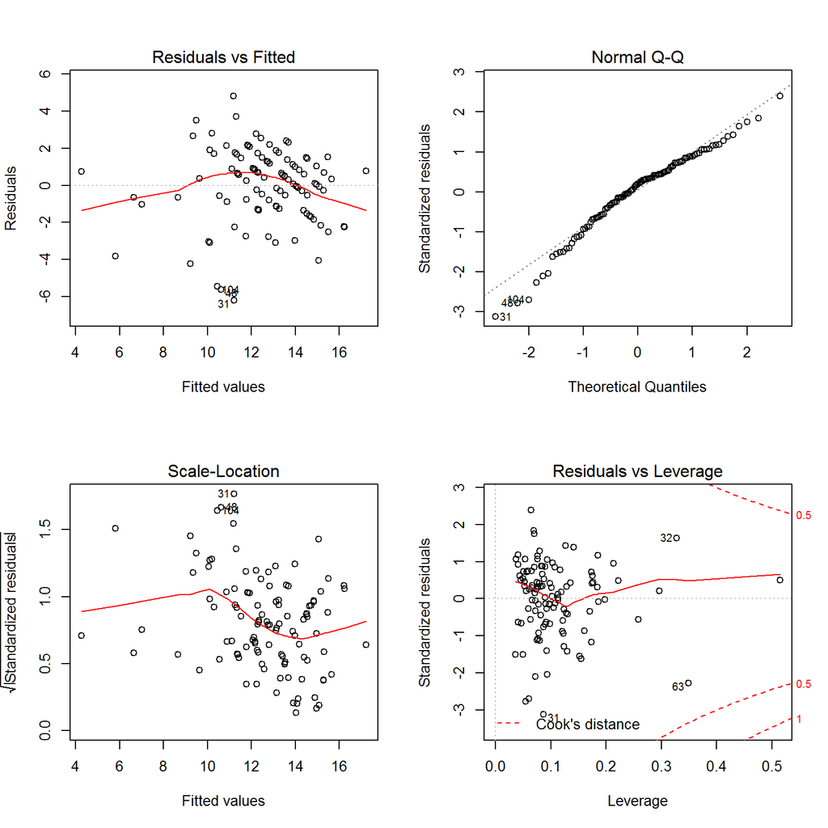

```r
par(mfrow=c(2,2))
plot(test_inter)
```

There are no outliers of concern (standardized residuals <4), the residuals look very normal, but the variance of the residuals appears to be non-constant.

Note that I did not test for any interactions between any other variables.

So at this point my final model is:

|  | Estimate | Std. Error | t value | Pr(>\|t\|) |
| --- | --- | --- | --- | --- |
| (Intercept) | 6.555 | 2.023 | 3.241 | 0.002 |
| AGE | 0.619 | 0.114 | 5.406 | 0.000 |
| GENDERMale | -1.751 | 0.443 | -3.950 | 0.000 |
| HOWREL2 | -2.033 | 0.759 | -2.679 | 0.009 |
| HOWREL3 | -1.576 | 0.816 | -1.932 | 0.056 |
| BSI_somat | 0.594 | 0.791 | 0.750 | 0.455 |
| s1 | -3.497 | 1.279 | -2.735 | 0.007 |
| NHOOKEY | 0.305 | 0.079 | 3.876 | 0.000 |
| BSI_paranoid | 0.684 | 0.325 | 2.106 | 0.038 |
| NGHB | -0.091 | 0.023 | -3.921 | 0.000 |
| BSI_interp | 0.083 | 0.400 | 0.207 | 0.837 |
| i1 | -4.468 | 1.543 | -2.895 | 0.005 |

After controlling for the age at survey, adolescents who are very religious or spiritual, those who skip school more, and those with a high value on the BSI paranoid scale are more likely to start drinking at a later age.

Adolescents with a high Interpersonal sensitivity BSI subscale value, a high value on the Somatization BSI subscale, and males are more likely to start drinking at an earlier age (all p<.01).

This model explains 49.6% of the variance in the outcome.